# (201902-fordgobike-tripdata)

## by (Mahmoud Wael Hamdy)

## Preliminary Wrangling

### What is the duration of most rides?

> I think the most duration of the trips is Approximately 6 mins

> In this plot I think analyzing the start and end day, hour, the month will give the same result, so I will only do my process on start time columns

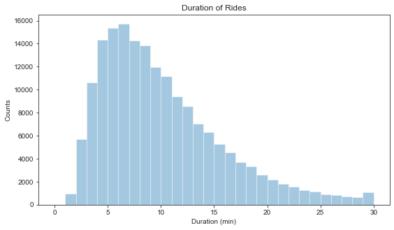

## What are the most popular start and end stations?

> Market St at 10th St and San Caltrain Francisco station2(townsend St at 4th St) are the most common start station

> San Caltrain Francisco station2(townsend St at 4th St )and Market St at 10th St are the most common end station

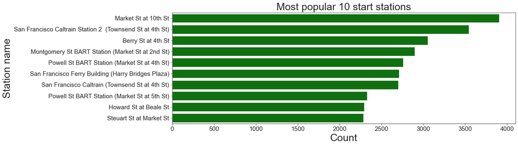

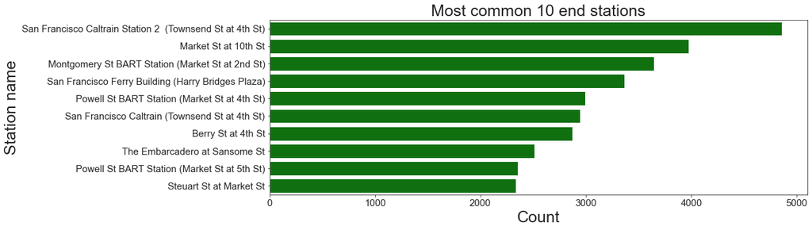

### What is the most common hour?

> 8 AM, 5 PM are the most common hours while hours from 12 am to 5 am are the least

> I think the hours are those from 7 to 9 in the morning and from 4 to 6 in the evening. This may be related to the time workers and students go to and leave work and school.

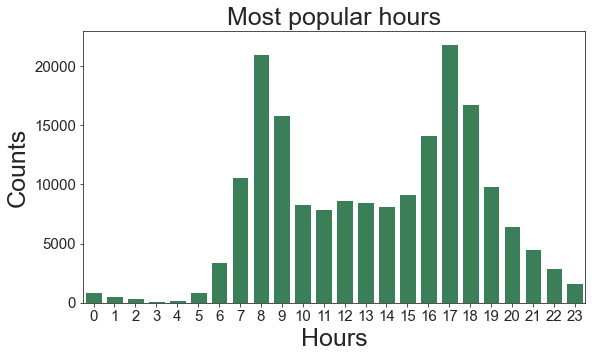

## What is the most common day in the week?

> Thursday andTuesday are the most common days, while Sunday and saturday is the least day

> Saturday and Sunday are the weekend in the United States of America.

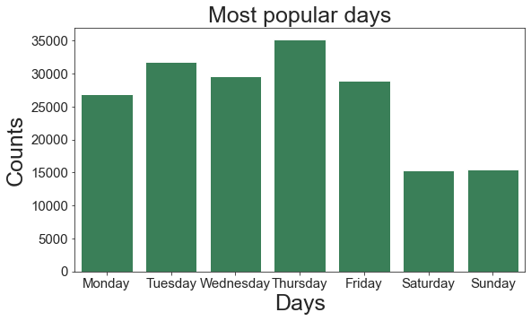

## What is the most common day in the month?

> Day 20 and 28 are the most common too, while 9 and 3 are the least

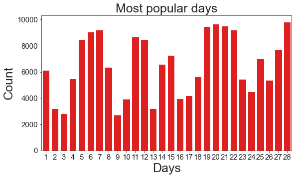

#### What is the most common user type?

> 10.8% of the riders are Custmoers while 89.2% are Subscriber.

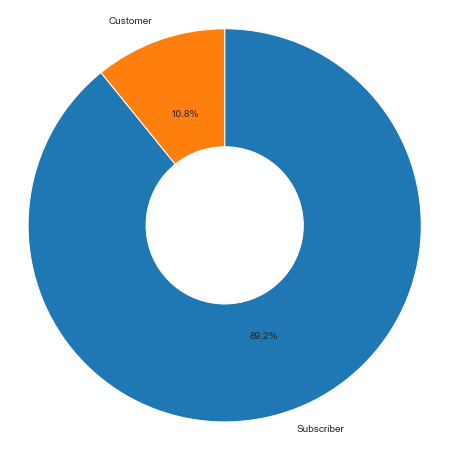

#### What is the most common gender?

> 74.6% of Male users,23.3% female ,and 2.1% other users

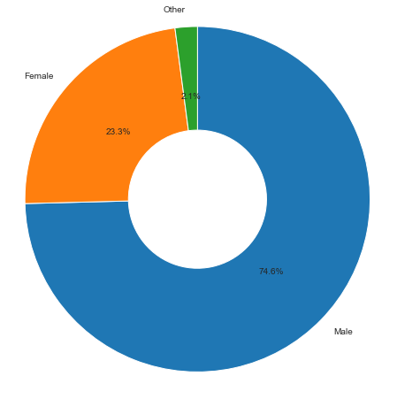

### What is the most bike ridden?

> bikes with id 4794 and 4814 are most in this data

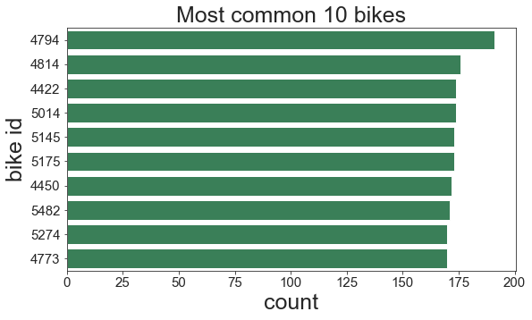

### What is the average duration for every user type?

> the average time which riders (customers) take type is higher than the average of Subscribers, the riders (customers) have longer trips, whereas Subscribers have shorter trips

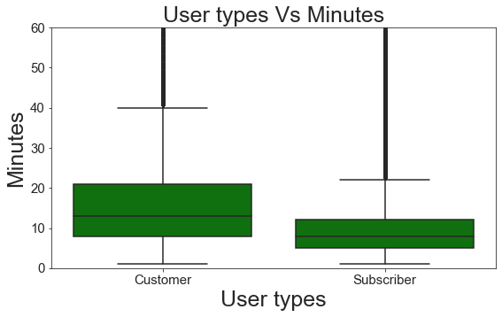

### What is the average duration formember gender?

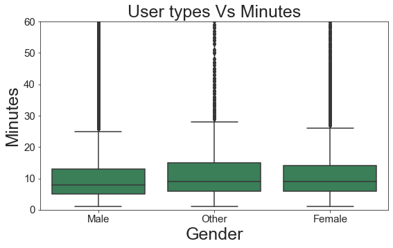

### Distribution of member_birth_year

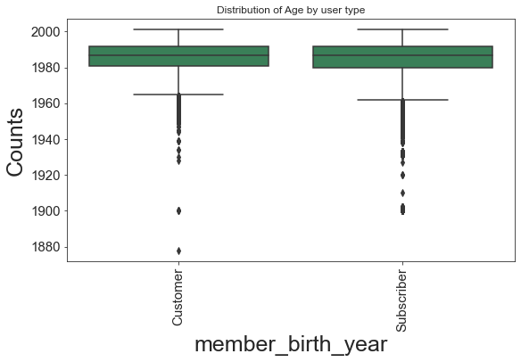

### What is the duration for the most common station?

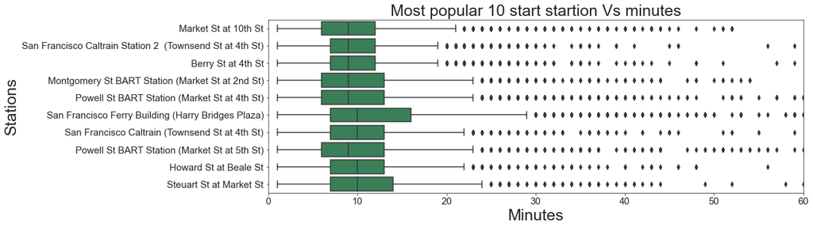

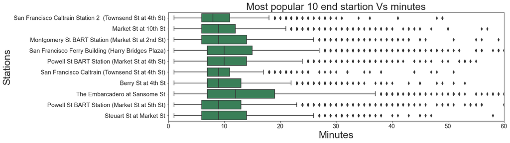

### What is the average duration of each day?

> the average of all days is around 10 minutes , but the average duration of Saturday and Sunday is more necessary bit than the others day,

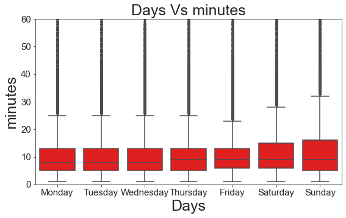

### What is the frequency of users type per hour?

> the hours for both user types are those from 7 - 9 am and from 4 - 6 pm. This might be related to the time when employees and students go to and leave work and school.

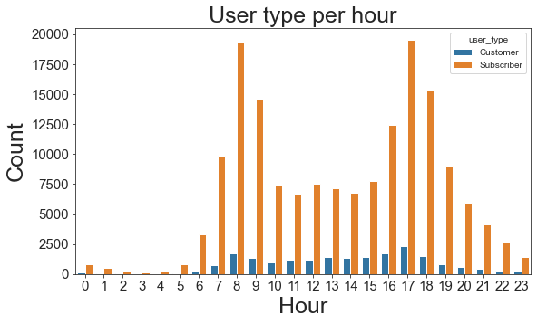

### What is the frequency of users type per day?

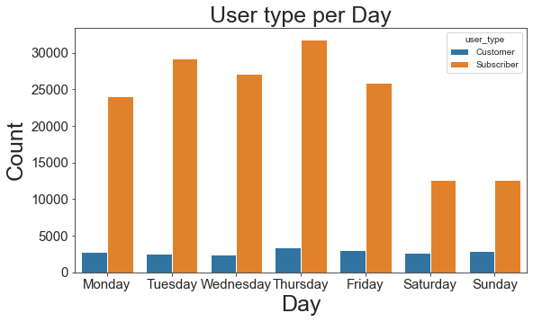

### Trip distribution over weekdays and by customer type

> Customers have consistently longer trips than subscribers

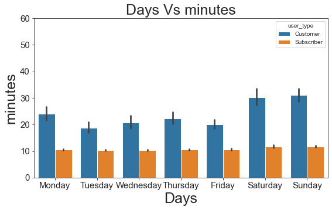

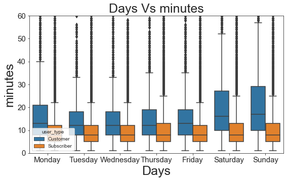

### Trip duration over day hours and by customer type

> customers have consistently higher trips across all hours of the day. However, customer trips are much longer at midnight and midday

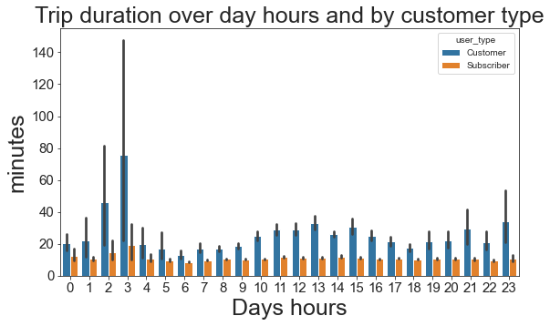

### Were there any interesting or surprising interactions between features?

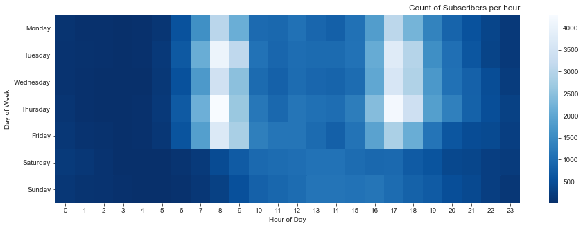

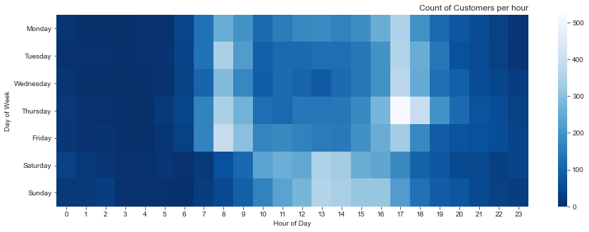